# Risk Factor Analysis

## Outcome Variable

**Outcome Variable:** haz

## Predictor Variables

**Intervention Variable:** mbmi

**Adjustment Set:**

unadjusted

## Stratifying Variables

The analysis was stratified on these variable(s):

- agecat
- studyid
- country

## Data Summary

| agecat | studyid | country | mbmi | n_cell | n |
| --- | --- | --- | --- | --- | --- |
| Birth | MAL-ED | BANGLADESH | Normal weight | 194 | 222 |
| Birth | MAL-ED | BANGLADESH | Underweight | 28 | 222 |
| Birth | MAL-ED | BRAZIL | Normal weight | 59 | 64 |
| Birth | MAL-ED | BRAZIL | Underweight | 5 | 64 |
| Birth | MAL-ED | INDIA | Normal weight | 35 | 43 |
| Birth | MAL-ED | INDIA | Underweight | 8 | 43 |
| Birth | MAL-ED | NEPAL | Normal weight | 27 | 27 |
| Birth | MAL-ED | NEPAL | Underweight | 0 | 27 |
| Birth | MAL-ED | PERU | Normal weight | 221 | 226 |
| Birth | MAL-ED | PERU | Underweight | 5 | 226 |
| Birth | MAL-ED | SOUTH AFRICA | Normal weight | 98 | 101 |
| Birth | MAL-ED | SOUTH AFRICA | Underweight | 3 | 101 |
| Birth | MAL-ED | TANZANIA, UNITED REPUBLIC OF | Normal weight | 115 | 122 |
| Birth | MAL-ED | TANZANIA, UNITED REPUBLIC OF | Underweight | 7 | 122 |
| Birth | NIH-Birth | BANGLADESH | Normal weight | 506 | 608 |
| Birth | NIH-Birth | BANGLADESH | Underweight | 102 | 608 |
| Birth | NIH-Crypto | BANGLADESH | Normal weight | 663 | 729 |
| Birth | NIH-Crypto | BANGLADESH | Underweight | 66 | 729 |
| Birth | PROBIT | BELARUS | Normal weight | 13203 | 13726 |
| Birth | PROBIT | BELARUS | Underweight | 523 | 13726 |
| Birth | PROVIDE | BANGLADESH | Normal weight | 418 | 517 |
| Birth | PROVIDE | BANGLADESH | Underweight | 99 | 517 |
| Birth | SAS-CompFeed | INDIA | Normal weight | 856 | 1134 |
| Birth | SAS-CompFeed | INDIA | Underweight | 278 | 1134 |
| Birth | ZVITAMBO | ZIMBABWE | Normal weight | 9162 | 9672 |
| Birth | ZVITAMBO | ZIMBABWE | Underweight | 510 | 9672 |
| 6 months | LCNI-5 | MALAWI | Normal weight | 691 | 836 |
| 6 months | LCNI-5 | MALAWI | Underweight | 145 | 836 |
| 6 months | MAL-ED | BANGLADESH | Normal weight | 209 | 241 |
| 6 months | MAL-ED | BANGLADESH | Underweight | 32 | 241 |

[output cut: 54 more lines]

The following strata were considered:

- agecat: 24 months, studyid: LCNI-5, country: MALAWI
- agecat: 24 months, studyid: MAL-ED, country: BANGLADESH
- agecat: 24 months, studyid: MAL-ED, country: BRAZIL
- agecat: 24 months, studyid: MAL-ED, country: INDIA
- agecat: 24 months, studyid: MAL-ED, country: NEPAL
- agecat: 24 months, studyid: MAL-ED, country: PERU
- agecat: 24 months, studyid: MAL-ED, country: SOUTH AFRICA
- agecat: 24 months, studyid: MAL-ED, country: TANZANIA, UNITED REPUBLIC OF
- agecat: 24 months, studyid: NIH-Birth, country: BANGLADESH
- agecat: 24 months, studyid: NIH-Crypto, country: BANGLADESH
- agecat: 24 months, studyid: PROBIT, country: BELARUS
- agecat: 24 months, studyid: PROVIDE, country: BANGLADESH
- agecat: 24 months, studyid: TanzaniaChild2, country: TANZANIA, UNITED REPUBLIC OF
- agecat: 24 months, studyid: ZVITAMBO, country: ZIMBABWE
- agecat: 6 months, studyid: LCNI-5, country: MALAWI
- agecat: 6 months, studyid: MAL-ED, country: BANGLADESH
- agecat: 6 months, studyid: MAL-ED, country: BRAZIL
- agecat: 6 months, studyid: MAL-ED, country: INDIA
- agecat: 6 months, studyid: MAL-ED, country: NEPAL
- agecat: 6 months, studyid: MAL-ED, country: PERU
- agecat: 6 months, studyid: MAL-ED, country: SOUTH AFRICA
- agecat: 6 months, studyid: MAL-ED, country: TANZANIA, UNITED REPUBLIC OF
- agecat: 6 months, studyid: NIH-Birth, country: BANGLADESH
- agecat: 6 months, studyid: NIH-Crypto, country: BANGLADESH
- agecat: 6 months, studyid: PROBIT, country: BELARUS
- agecat: 6 months, studyid: PROVIDE, country: BANGLADESH
- agecat: 6 months, studyid: SAS-CompFeed, country: INDIA
- agecat: 6 months, studyid: TanzaniaChild2, country: TANZANIA, UNITED REPUBLIC OF
- agecat: 6 months, studyid: ZVITAMBO, country: ZIMBABWE
- agecat: Birth, studyid: MAL-ED, country: BANGLADESH
- agecat: Birth, studyid: MAL-ED, country: BRAZIL
- agecat: Birth, studyid: MAL-ED, country: INDIA
- agecat: Birth, studyid: MAL-ED, country: NEPAL
- agecat: Birth, studyid: MAL-ED, country: PERU
- agecat: Birth, studyid: MAL-ED, country: SOUTH AFRICA
- agecat: Birth, studyid: MAL-ED, country: TANZANIA, UNITED REPUBLIC OF
- agecat: Birth, studyid: NIH-Birth, country: BANGLADESH
- agecat: Birth, studyid: NIH-Crypto, country: BANGLADESH
- agecat: Birth, studyid: PROBIT, country: BELARUS
- agecat: Birth, studyid: PROVIDE, country: BANGLADESH
- agecat: Birth, studyid: SAS-CompFeed, country: INDIA
- agecat: Birth, studyid: ZVITAMBO, country: ZIMBABWE

### Dropped Strata

Some strata were dropped due to rare outcomes:

- agecat: Birth, studyid: MAL-ED, country: NEPAL
- agecat: Birth, studyid: MAL-ED, country: SOUTH AFRICA
- agecat: 6 months, studyid: MAL-ED, country: NEPAL
- agecat: 24 months, studyid: MAL-ED, country: NEPAL
- agecat: 24 months, studyid: MAL-ED, country: PERU
- agecat: 24 months, studyid: TanzaniaChild2, country: TANZANIA, UNITED REPUBLIC OF

## Methods Detail

We’re interested in the causal parameters $E[Y_a]$ for all values of $a \in \mathcal{A}$. These parameters represent the mean outcome if, possibly contrary to fact, we intervened to set all units to have $A=a$. Under the randomization and positivity assumptions, these are identified by the statistical parameters $\psi_a=E_W[E_{Y|A,W}(Y|A=a,W)]$. In addition, we’re interested in the mean of $Y$, $E[Y]$ under no intervention (the observed mean). We will estimate these parameters by using SuperLearner to fit the relevant likelihood factors – $E_{Y|A,W}(Y|A=a,W)$ and $p(A=a|W)$, and then updating our likelihood fit using a joint TMLE.

For unadjusted analyses ($W=\{\}$), initial likelihoods were estimated using Lrnr_glm to estimate the simple $E(Y|A)$ and Lrnr_mean to estimate $p(A)$. For adjusted analyses, a small library containing Lrnr_glmnet, Lrnr_xgboost, and Lrnr_mean was used.

Having estimated these parameters, we will then use the delta method to estimate relative risks and attributable risks relative to a prespecified baseline level of $A$.

# Results Detail

## Results Plots

[figure not shown]

[figure not shown]

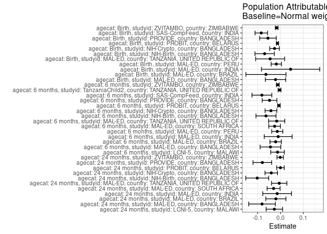

## Results Table

### Parameter: TSM

| agecat | studyid | country | intervention_level | baseline_level | estimate | ci_lower | ci_upper |
| --- | --- | --- | --- | --- | --- | --- | --- |
| Birth | MAL-ED | BANGLADESH | Normal weight | NA | -1.0563402 | -1.2029937 | -0.9096867 |
| Birth | MAL-ED | BANGLADESH | Underweight | NA | -1.2271429 | -1.5419635 | -0.9123222 |
| Birth | MAL-ED | BRAZIL | Normal weight | NA | -0.6249153 | -0.9137560 | -0.3360745 |
| Birth | MAL-ED | BRAZIL | Underweight | NA | -1.4380000 | -2.2732876 | -0.6027124 |
| Birth | MAL-ED | INDIA | Normal weight | NA | -1.2745714 | -1.6299983 | -0.9191446 |
| Birth | MAL-ED | INDIA | Underweight | NA | -1.0362500 | -1.6020040 | -0.4704960 |
| Birth | MAL-ED | PERU | Normal weight | NA | -0.8869683 | -1.0065725 | -0.7673641 |
| Birth | MAL-ED | PERU | Underweight | NA | -1.7080000 | -2.3409322 | -1.0750678 |
| Birth | MAL-ED | TANZANIA, UNITED REPUBLIC OF | Normal weight | NA | -1.0913043 | -1.3056634 | -0.8769453 |
| Birth | MAL-ED | TANZANIA, UNITED REPUBLIC OF | Underweight | NA | -1.8785714 | -2.8008825 | -0.9562603 |
| Birth | NIH-Birth | BANGLADESH | Normal weight | NA | -0.8617391 | -0.9574222 | -0.7660561 |
| Birth | NIH-Birth | BANGLADESH | Underweight | NA | -1.2747059 | -1.4960871 | -1.0533247 |
| Birth | NIH-Crypto | BANGLADESH | Normal weight | NA | -0.8830015 | -0.9587845 | -0.8072185 |
| Birth | NIH-Crypto | BANGLADESH | Underweight | NA | -1.1692424 | -1.3780475 | -0.9604373 |
| Birth | PROBIT | BELARUS | Normal weight | NA | 1.3249655 | 1.1649386 | 1.4849925 |
| Birth | PROBIT | BELARUS | Underweight | NA | 0.9809751 | 0.8003150 | 1.1616352 |
| Birth | PROVIDE | BANGLADESH | Normal weight | NA | -0.8377273 | -0.9230426 | -0.7524119 |
| Birth | PROVIDE | BANGLADESH | Underweight | NA | -1.1238384 | -1.2852147 | -0.9624621 |
| Birth | SAS-CompFeed | INDIA | Normal weight | NA | -1.3601636 | -1.4546724 | -1.2656547 |
| Birth | SAS-CompFeed | INDIA | Underweight | NA | -1.7030576 | -1.8275375 | -1.5785776 |
| Birth | ZVITAMBO | ZIMBABWE | Normal weight | NA | -0.4598963 | -0.4849627 | -0.4348299 |
| Birth | ZVITAMBO | ZIMBABWE | Underweight | NA | -0.7736667 | -0.8829885 | -0.6643448 |
| 6 months | LCNI-5 | MALAWI | Normal weight | NA | -1.6449928 | -1.7230655 | -1.5669201 |
| 6 months | LCNI-5 | MALAWI | Underweight | NA | -1.7186897 | -1.8709913 | -1.5663880 |
| 6 months | MAL-ED | BANGLADESH | Normal weight | NA | -1.1611563 | -1.2872935 | -1.0350191 |
| 6 months | MAL-ED | BANGLADESH | Underweight | NA | -1.4913021 | -1.7900815 | -1.1925227 |
| 6 months | MAL-ED | BRAZIL | Normal weight | NA | 0.0708375 | -0.0781476 | 0.2198227 |
| 6 months | MAL-ED | BRAZIL | Underweight | NA | -0.4164815 | -0.8769172 | 0.0439543 |
| 6 months | MAL-ED | INDIA | Normal weight | NA | -1.1959677 | -1.3287755 | -1.0631600 |
| 6 months | MAL-ED | INDIA | Underweight | NA | -1.2438776 | -1.5043669 | -0.9833882 |
| 6 months | MAL-ED | PERU | Normal weight | NA | -1.3101467 | -1.4185443 | -1.2017491 |
| 6 months | MAL-ED | PERU | Underweight | NA | -2.0693333 | -2.9031517 | -1.2355150 |
| 6 months | MAL-ED | SOUTH AFRICA | Normal weight | NA | -1.0471625 | -1.1780920 | -0.9162331 |
| 6 months | MAL-ED | SOUTH AFRICA | Underweight | NA | -1.9571429 | -2.5636947 | -1.3505910 |
| 6 months | MAL-ED | TANZANIA, UNITED REPUBLIC OF | Normal weight | NA | -1.3521674 | -1.4761528 | -1.2281819 |
| 6 months | MAL-ED | TANZANIA, UNITED REPUBLIC OF | Underweight | NA | -1.6446429 | -2.2397609 | -1.0495248 |
| 6 months | NIH-Birth | BANGLADESH | Normal weight | NA | -1.3439959 | -1.4393323 | -1.2486594 |
| 6 months | NIH-Birth | BANGLADESH | Underweight | NA | -1.7100000 | -1.9345841 | -1.4854159 |
| 6 months | NIH-Crypto | BANGLADESH | Normal weight | NA | -1.1568519 | -1.2307776 | -1.0829261 |
| 6 months | NIH-Crypto | BANGLADESH | Underweight | NA | -1.6032090 | -1.8466359 | -1.3597820 |
| 6 months | PROBIT | BELARUS | Normal weight | NA | 0.1144941 | 0.0249286 | 0.2040597 |
| 6 months | PROBIT | BELARUS | Underweight | NA | -0.0627426 | -0.2506696 | 0.1251844 |
| 6 months | PROVIDE | BANGLADESH | Normal weight | NA | -1.0417001 | -1.1248748 | -0.9585254 |
| 6 months | PROVIDE | BANGLADESH | Underweight | NA | -1.3163810 | -1.4738524 | -1.1589095 |
| 6 months | SAS-CompFeed | INDIA | Normal weight | NA | -1.3259056 | -1.4254990 | -1.2263123 |
| 6 months | SAS-CompFeed | INDIA | Underweight | NA | -1.6530328 | -1.7747813 | -1.5312843 |
| 6 months | TanzaniaChild2 | TANZANIA, UNITED REPUBLIC OF | Normal weight | NA | -0.5365944 | -0.5868803 | -0.4863086 |
| 6 months | TanzaniaChild2 | TANZANIA, UNITED REPUBLIC OF | Underweight | NA | -0.7685294 | -1.0128208 | -0.5242380 |
| 6 months | ZVITAMBO | ZIMBABWE | Normal weight | NA | -0.8682883 | -0.8964470 | -0.8401297 |
| 6 months | ZVITAMBO | ZIMBABWE | Underweight | NA | -1.0990027 | -1.2155579 | -0.9824474 |
| 24 months | LCNI-5 | MALAWI | Normal weight | NA | -1.8583817 | -1.9474335 | -1.7693299 |
| 24 months | LCNI-5 | MALAWI | Underweight | NA | -2.0211579 | -2.2181083 | -1.8242075 |
| 24 months | MAL-ED | BANGLADESH | Normal weight | NA | -1.8977596 | -2.0295876 | -1.7659316 |
| 24 months | MAL-ED | BANGLADESH | Underweight | NA | -2.4872414 | -2.8406819 | -2.1338009 |
| 24 months | MAL-ED | BRAZIL | Normal weight | NA | 0.0261008 | -0.1439691 | 0.1961708 |
| 24 months | MAL-ED | BRAZIL | Underweight | NA | -0.5391667 | -1.6773310 | 0.5989977 |
| 24 months | MAL-ED | INDIA | Normal weight | NA | -1.8699444 | -2.0106935 | -1.7291954 |
| 24 months | MAL-ED | INDIA | Underweight | NA | -1.9413043 | -2.2159117 | -1.6666970 |
| 24 months | MAL-ED | SOUTH AFRICA | Normal weight | NA | -1.6131241 | -1.7506877 | -1.4755605 |
| 24 months | MAL-ED | SOUTH AFRICA | Underweight | NA | -2.6192857 | -3.1998173 | -2.0387542 |
| 24 months | MAL-ED | TANZANIA, UNITED REPUBLIC OF | Normal weight | NA | -2.6400985 | -2.7783602 | -2.5018368 |
| 24 months | MAL-ED | TANZANIA, UNITED REPUBLIC OF | Underweight | NA | -2.7463636 | -3.3791683 | -2.1135590 |
| 24 months | NIH-Birth | BANGLADESH | Normal weight | NA | -2.1174713 | -2.2306922 | -2.0042505 |
| 24 months | NIH-Birth | BANGLADESH | Underweight | NA | -2.6622292 | -2.8805156 | -2.4439427 |
| 24 months | NIH-Crypto | BANGLADESH | Normal weight | NA | -1.4009979 | -1.4875969 | -1.3143989 |
| 24 months | NIH-Crypto | BANGLADESH | Underweight | NA | -1.8823256 | -2.1670596 | -1.5975916 |
| 24 months | PROBIT | BELARUS | Normal weight | NA | -0.1442950 | -0.4300018 | 0.1414117 |
| 24 months | PROBIT | BELARUS | Underweight | NA | -0.1476761 | -0.6179677 | 0.3226156 |
| 24 months | PROVIDE | BANGLADESH | Normal weight | NA | -1.5209958 | -1.6108678 | -1.4311239 |
| 24 months | PROVIDE | BANGLADESH | Underweight | NA | -1.9783500 | -2.1805873 | -1.7761127 |
| 24 months | ZVITAMBO | ZIMBABWE | Normal weight | NA | -1.5970922 | -1.6606064 | -1.5335781 |
| 24 months | ZVITAMBO | ZIMBABWE | Underweight | NA | -1.6247541 | -1.9303196 | -1.3191886 |

### Parameter: E(Y)

| agecat | studyid | country | intervention_level | baseline_level | estimate | ci_lower | ci_upper |
| --- | --- | --- | --- | --- | --- | --- | --- |
| Birth | MAL-ED | BANGLADESH | NA | NA | -1.0778829 | -1.2122580 | -0.9435077 |
| Birth | MAL-ED | BRAZIL | NA | NA | -0.6884375 | -0.9678371 | -0.4090379 |
| Birth | MAL-ED | INDIA | NA | NA | -1.2302326 | -1.5393614 | -0.9211037 |
| Birth | MAL-ED | PERU | NA | NA | -0.9051327 | -1.0238686 | -0.7863969 |
| Birth | MAL-ED | TANZANIA, UNITED REPUBLIC OF | NA | NA | -1.1364754 | -1.3478823 | -0.9250686 |
| Birth | NIH-Birth | BANGLADESH | NA | NA | -0.9310197 | -1.0197391 | -0.8423003 |
| Birth | NIH-Crypto | BANGLADESH | NA | NA | -0.9089163 | -0.9806324 | -0.8372002 |
| Birth | PROBIT | BELARUS | NA | NA | 1.3118585 | 1.1523374 | 1.4713797 |
| Birth | PROVIDE | BANGLADESH | NA | NA | -0.8925145 | -0.9687201 | -0.8163089 |
| Birth | SAS-CompFeed | INDIA | NA | NA | -1.4442240 | -1.5343470 | -1.3541010 |
| Birth | ZVITAMBO | ZIMBABWE | NA | NA | -0.4764413 | -0.5009156 | -0.4519670 |
| 6 months | LCNI-5 | MALAWI | NA | NA | -1.6577751 | -1.7275296 | -1.5880207 |
| 6 months | MAL-ED | BANGLADESH | NA | NA | -1.2049931 | -1.3222136 | -1.0877726 |
| 6 months | MAL-ED | BRAZIL | NA | NA | 0.0497516 | -0.0948051 | 0.1943083 |
| 6 months | MAL-ED | INDIA | NA | NA | -1.2059574 | -1.3243030 | -1.0876119 |
| 6 months | MAL-ED | PERU | NA | NA | -1.3241023 | -1.4325083 | -1.2156964 |
| 6 months | MAL-ED | SOUTH AFRICA | NA | NA | -1.0727443 | -1.2024880 | -0.9430006 |
| 6 months | MAL-ED | TANZANIA, UNITED REPUBLIC OF | NA | NA | -1.3687449 | -1.4907629 | -1.2467270 |
| 6 months | NIH-Birth | BANGLADESH | NA | NA | -1.4073821 | -1.4960598 | -1.3187043 |
| 6 months | NIH-Crypto | BANGLADESH | NA | NA | -1.1986783 | -1.2700937 | -1.1272630 |
| 6 months | PROBIT | BELARUS | NA | NA | 0.1076224 | 0.0168411 | 0.1984037 |
| 6 months | PROVIDE | BANGLADESH | NA | NA | -1.0895301 | -1.1639589 | -1.0151013 |
| 6 months | SAS-CompFeed | INDIA | NA | NA | -1.4072209 | -1.4983514 | -1.3160903 |
| 6 months | TanzaniaChild2 | TANZANIA, UNITED REPUBLIC OF | NA | NA | -0.5405711 | -0.5899965 | -0.4911457 |
| 6 months | ZVITAMBO | ZIMBABWE | NA | NA | -0.8800508 | -0.9074511 | -0.8526506 |
| 24 months | LCNI-5 | MALAWI | NA | NA | -1.8851820 | -1.9664818 | -1.8038822 |
| 24 months | MAL-ED | BANGLADESH | NA | NA | -1.9783962 | -2.1050210 | -1.8517715 |
| 24 months | MAL-ED | BRAZIL | NA | NA | 0.0059127 | -0.1637934 | 0.1756188 |
| 24 months | MAL-ED | INDIA | NA | NA | -1.8844690 | -2.0097879 | -1.7591502 |
| 24 months | MAL-ED | SOUTH AFRICA | NA | NA | -1.6432229 | -1.7795844 | -1.5068615 |
| 24 months | MAL-ED | TANZANIA, UNITED REPUBLIC OF | NA | NA | -2.6455607 | -2.7807256 | -2.5103959 |
| 24 months | NIH-Birth | BANGLADESH | NA | NA | -2.2190579 | -2.3217459 | -2.1163699 |
| 24 months | NIH-Crypto | BANGLADESH | NA | NA | -1.4412646 | -1.5249156 | -1.3576135 |
| 24 months | PROBIT | BELARUS | NA | NA | -0.1444149 | -0.4258602 | 0.1370304 |
| 24 months | PROVIDE | BANGLADESH | NA | NA | -1.6002600 | -1.6836163 | -1.5169036 |
| 24 months | ZVITAMBO | ZIMBABWE | NA | NA | -1.5983212 | -1.6605141 | -1.5361283 |

### Parameter: ATE

| agecat | studyid | country | intervention_level | baseline_level | estimate | ci_lower | ci_upper |
| --- | --- | --- | --- | --- | --- | --- | --- |
| Birth | MAL-ED | BANGLADESH | Normal weight | Normal weight | 0.0000000 | 0.0000000 | 0.0000000 |
| Birth | MAL-ED | BANGLADESH | Underweight | Normal weight | -0.1708027 | -0.5181055 | 0.1765002 |
| Birth | MAL-ED | BRAZIL | Normal weight | Normal weight | 0.0000000 | 0.0000000 | 0.0000000 |
| Birth | MAL-ED | BRAZIL | Underweight | Normal weight | -0.8130847 | -1.6969028 | 0.0707333 |
| Birth | MAL-ED | INDIA | Normal weight | Normal weight | 0.0000000 | 0.0000000 | 0.0000000 |
| Birth | MAL-ED | INDIA | Underweight | Normal weight | 0.2383214 | -0.4298147 | 0.9064576 |
| Birth | MAL-ED | PERU | Normal weight | Normal weight | 0.0000000 | 0.0000000 | 0.0000000 |
| Birth | MAL-ED | PERU | Underweight | Normal weight | -0.8210317 | -1.4651655 | -0.1768979 |
| Birth | MAL-ED | TANZANIA, UNITED REPUBLIC OF | Normal weight | Normal weight | 0.0000000 | 0.0000000 | 0.0000000 |
| Birth | MAL-ED | TANZANIA, UNITED REPUBLIC OF | Underweight | Normal weight | -0.7872671 | -1.7341607 | 0.1596266 |
| Birth | NIH-Birth | BANGLADESH | Normal weight | Normal weight | 0.0000000 | 0.0000000 | 0.0000000 |
| Birth | NIH-Birth | BANGLADESH | Underweight | Normal weight | -0.4129668 | -0.6541407 | -0.1717928 |
| Birth | NIH-Crypto | BANGLADESH | Normal weight | Normal weight | 0.0000000 | 0.0000000 | 0.0000000 |
| Birth | NIH-Crypto | BANGLADESH | Underweight | Normal weight | -0.2862409 | -0.5083729 | -0.0641089 |
| Birth | PROBIT | BELARUS | Normal weight | Normal weight | 0.0000000 | 0.0000000 | 0.0000000 |
| Birth | PROBIT | BELARUS | Underweight | Normal weight | -0.3439904 | -0.4703953 | -0.2175855 |
| Birth | PROVIDE | BANGLADESH | Normal weight | Normal weight | 0.0000000 | 0.0000000 | 0.0000000 |
| Birth | PROVIDE | BANGLADESH | Underweight | Normal weight | -0.2861111 | -0.4686515 | -0.1035707 |
| Birth | SAS-CompFeed | INDIA | Normal weight | Normal weight | 0.0000000 | 0.0000000 | 0.0000000 |
| Birth | SAS-CompFeed | INDIA | Underweight | Normal weight | -0.3428940 | -0.4245868 | -0.2612012 |
| Birth | ZVITAMBO | ZIMBABWE | Normal weight | Normal weight | 0.0000000 | 0.0000000 | 0.0000000 |
| Birth | ZVITAMBO | ZIMBABWE | Underweight | Normal weight | -0.3137704 | -0.4259291 | -0.2016116 |
| 6 months | LCNI-5 | MALAWI | Normal weight | Normal weight | 0.0000000 | 0.0000000 | 0.0000000 |
| 6 months | LCNI-5 | MALAWI | Underweight | Normal weight | -0.0736969 | -0.2448434 | 0.0974496 |
| 6 months | MAL-ED | BANGLADESH | Normal weight | Normal weight | 0.0000000 | 0.0000000 | 0.0000000 |
| 6 months | MAL-ED | BANGLADESH | Underweight | Normal weight | -0.3301458 | -0.6544600 | -0.0058315 |
| 6 months | MAL-ED | BRAZIL | Normal weight | Normal weight | 0.0000000 | 0.0000000 | 0.0000000 |
| 6 months | MAL-ED | BRAZIL | Underweight | Normal weight | -0.4873190 | -0.9712587 | -0.0033793 |
| 6 months | MAL-ED | INDIA | Normal weight | Normal weight | 0.0000000 | 0.0000000 | 0.0000000 |
| 6 months | MAL-ED | INDIA | Underweight | Normal weight | -0.0479098 | -0.3403010 | 0.2444814 |
| 6 months | MAL-ED | PERU | Normal weight | Normal weight | 0.0000000 | 0.0000000 | 0.0000000 |
| 6 months | MAL-ED | PERU | Underweight | Normal weight | -0.7591866 | -1.6000214 | 0.0816481 |
| 6 months | MAL-ED | SOUTH AFRICA | Normal weight | Normal weight | 0.0000000 | 0.0000000 | 0.0000000 |
| 6 months | MAL-ED | SOUTH AFRICA | Underweight | Normal weight | -0.9099803 | -1.5305024 | -0.2894583 |
| 6 months | MAL-ED | TANZANIA, UNITED REPUBLIC OF | Normal weight | Normal weight | 0.0000000 | 0.0000000 | 0.0000000 |
| 6 months | MAL-ED | TANZANIA, UNITED REPUBLIC OF | Underweight | Normal weight | -0.2924755 | -0.9003718 | 0.3154208 |
| 6 months | NIH-Birth | BANGLADESH | Normal weight | Normal weight | 0.0000000 | 0.0000000 | 0.0000000 |
| 6 months | NIH-Birth | BANGLADESH | Underweight | Normal weight | -0.3660041 | -0.6099858 | -0.1220224 |
| 6 months | NIH-Crypto | BANGLADESH | Normal weight | Normal weight | 0.0000000 | 0.0000000 | 0.0000000 |
| 6 months | NIH-Crypto | BANGLADESH | Underweight | Normal weight | -0.4463571 | -0.7007617 | -0.1919525 |
| 6 months | PROBIT | BELARUS | Normal weight | Normal weight | 0.0000000 | 0.0000000 | 0.0000000 |
| 6 months | PROBIT | BELARUS | Underweight | Normal weight | -0.1772367 | -0.3232782 | -0.0311952 |
| 6 months | PROVIDE | BANGLADESH | Normal weight | Normal weight | 0.0000000 | 0.0000000 | 0.0000000 |
| 6 months | PROVIDE | BANGLADESH | Underweight | Normal weight | -0.2746808 | -0.4527687 | -0.0965929 |
| 6 months | SAS-CompFeed | INDIA | Normal weight | Normal weight | 0.0000000 | 0.0000000 | 0.0000000 |
| 6 months | SAS-CompFeed | INDIA | Underweight | Normal weight | -0.3271271 | -0.4684775 | -0.1857768 |
| 6 months | TanzaniaChild2 | TANZANIA, UNITED REPUBLIC OF | Normal weight | Normal weight | 0.0000000 | 0.0000000 | 0.0000000 |
| 6 months | TanzaniaChild2 | TANZANIA, UNITED REPUBLIC OF | Underweight | Normal weight | -0.2319350 | -0.4813482 | 0.0174782 |
| 6 months | ZVITAMBO | ZIMBABWE | Normal weight | Normal weight | 0.0000000 | 0.0000000 | 0.0000000 |
| 6 months | ZVITAMBO | ZIMBABWE | Underweight | Normal weight | -0.2307143 | -0.3506228 | -0.1108059 |
| 24 months | LCNI-5 | MALAWI | Normal weight | Normal weight | 0.0000000 | 0.0000000 | 0.0000000 |
| 24 months | LCNI-5 | MALAWI | Underweight | Normal weight | -0.1627762 | -0.3789235 | 0.0533712 |
| 24 months | MAL-ED | BANGLADESH | Normal weight | Normal weight | 0.0000000 | 0.0000000 | 0.0000000 |
| 24 months | MAL-ED | BANGLADESH | Underweight | Normal weight | -0.5894818 | -0.9667070 | -0.2122567 |
| 24 months | MAL-ED | BRAZIL | Normal weight | Normal weight | 0.0000000 | 0.0000000 | 0.0000000 |
| 24 months | MAL-ED | BRAZIL | Underweight | Normal weight | -0.5652675 | -1.7160680 | 0.5855330 |
| 24 months | MAL-ED | INDIA | Normal weight | Normal weight | 0.0000000 | 0.0000000 | 0.0000000 |
| 24 months | MAL-ED | INDIA | Underweight | Normal weight | -0.0713599 | -0.3799364 | 0.2372166 |
| 24 months | MAL-ED | SOUTH AFRICA | Normal weight | Normal weight | 0.0000000 | 0.0000000 | 0.0000000 |
| 24 months | MAL-ED | SOUTH AFRICA | Underweight | Normal weight | -1.0061616 | -1.6027692 | -0.4095540 |
| 24 months | MAL-ED | TANZANIA, UNITED REPUBLIC OF | Normal weight | Normal weight | 0.0000000 | 0.0000000 | 0.0000000 |
| 24 months | MAL-ED | TANZANIA, UNITED REPUBLIC OF | Underweight | Normal weight | -0.1062651 | -0.7539981 | 0.5414679 |
| 24 months | NIH-Birth | BANGLADESH | Normal weight | Normal weight | 0.0000000 | 0.0000000 | 0.0000000 |
| 24 months | NIH-Birth | BANGLADESH | Underweight | Normal weight | -0.5447578 | -0.7906601 | -0.2988556 |
| 24 months | NIH-Crypto | BANGLADESH | Normal weight | Normal weight | 0.0000000 | 0.0000000 | 0.0000000 |
| 24 months | NIH-Crypto | BANGLADESH | Underweight | Normal weight | -0.4813277 | -0.7789396 | -0.1837158 |
| 24 months | PROBIT | BELARUS | Normal weight | Normal weight | 0.0000000 | 0.0000000 | 0.0000000 |
| 24 months | PROBIT | BELARUS | Underweight | Normal weight | -0.0033810 | -0.4675982 | 0.4608361 |
| 24 months | PROVIDE | BANGLADESH | Normal weight | Normal weight | 0.0000000 | 0.0000000 | 0.0000000 |
| 24 months | PROVIDE | BANGLADESH | Underweight | Normal weight | -0.4573542 | -0.6786614 | -0.2360470 |
| 24 months | ZVITAMBO | ZIMBABWE | Normal weight | Normal weight | 0.0000000 | 0.0000000 | 0.0000000 |
| 24 months | ZVITAMBO | ZIMBABWE | Underweight | Normal weight | -0.0276619 | -0.3397585 | 0.2844348 |

### Parameter: PAR

| agecat | studyid | country | intervention_level | baseline_level | estimate | ci_lower | ci_upper |
| --- | --- | --- | --- | --- | --- | --- | --- |
| Birth | MAL-ED | BANGLADESH | Normal weight | NA | -0.0215427 | -0.0659800 | 0.0228947 |
| Birth | MAL-ED | BRAZIL | Normal weight | NA | -0.0635222 | -0.1511062 | 0.0240617 |
| Birth | MAL-ED | INDIA | Normal weight | NA | 0.0443389 | -0.0830905 | 0.1717683 |
| Birth | MAL-ED | PERU | Normal weight | NA | -0.0181644 | -0.0407101 | 0.0043812 |
| Birth | MAL-ED | TANZANIA, UNITED REPUBLIC OF | Normal weight | NA | -0.0451711 | -0.1085427 | 0.0182006 |
| Birth | NIH-Birth | BANGLADESH | Normal weight | NA | -0.0692806 | -0.1115619 | -0.0269993 |
| Birth | NIH-Crypto | BANGLADESH | Normal weight | NA | -0.0259148 | -0.0468919 | -0.0049377 |
| Birth | PROBIT | BELARUS | Normal weight | NA | -0.0131070 | -0.0179115 | -0.0083025 |
| Birth | PROVIDE | BANGLADESH | Normal weight | NA | -0.0547872 | -0.0910663 | -0.0185082 |
| Birth | SAS-CompFeed | INDIA | Normal weight | NA | -0.0840604 | -0.1112188 | -0.0569021 |
| Birth | ZVITAMBO | ZIMBABWE | Normal weight | NA | -0.0165450 | -0.0226219 | -0.0104680 |
| 6 months | LCNI-5 | MALAWI | Normal weight | NA | -0.0127824 | -0.0425271 | 0.0169624 |
| 6 months | MAL-ED | BANGLADESH | Normal weight | NA | -0.0438368 | -0.0891718 | 0.0014983 |
| 6 months | MAL-ED | BRAZIL | Normal weight | NA | -0.0210859 | -0.0460040 | 0.0038322 |
| 6 months | MAL-ED | INDIA | Normal weight | NA | -0.0099897 | -0.0710074 | 0.0510279 |
| 6 months | MAL-ED | PERU | Normal weight | NA | -0.0139556 | -0.0382312 | 0.0103199 |
| 6 months | MAL-ED | SOUTH AFRICA | Normal weight | NA | -0.0255818 | -0.0511699 | 0.0000064 |
| 6 months | MAL-ED | TANZANIA, UNITED REPUBLIC OF | Normal weight | NA | -0.0165776 | -0.0520545 | 0.0188994 |
| 6 months | NIH-Birth | BANGLADESH | Normal weight | NA | -0.0633862 | -0.1072366 | -0.0195358 |
| 6 months | NIH-Crypto | BANGLADESH | Normal weight | NA | -0.0418265 | -0.0675042 | -0.0161487 |
| 6 months | PROBIT | BELARUS | Normal weight | NA | -0.0068717 | -0.0125226 | -0.0012209 |
| 6 months | PROVIDE | BANGLADESH | Normal weight | NA | -0.0478300 | -0.0799373 | -0.0157227 |
| 6 months | SAS-CompFeed | INDIA | Normal weight | NA | -0.0813152 | -0.1247301 | -0.0379003 |
| 6 months | TanzaniaChild2 | TANZANIA, UNITED REPUBLIC OF | Normal weight | NA | -0.0039767 | -0.0103514 | 0.0023980 |
| 6 months | ZVITAMBO | ZIMBABWE | Normal weight | NA | -0.0117625 | -0.0179846 | -0.0055405 |
| 24 months | LCNI-5 | MALAWI | Normal weight | NA | -0.0268002 | -0.0627276 | 0.0091271 |
| 24 months | MAL-ED | BANGLADESH | Normal weight | NA | -0.0806367 | -0.1390296 | -0.0222437 |
| 24 months | MAL-ED | BRAZIL | Normal weight | NA | -0.0201881 | -0.0642601 | 0.0238838 |
| 24 months | MAL-ED | INDIA | Normal weight | NA | -0.0145246 | -0.0774443 | 0.0483951 |
| 24 months | MAL-ED | SOUTH AFRICA | Normal weight | NA | -0.0300989 | -0.0584341 | -0.0017637 |
| 24 months | MAL-ED | TANZANIA, UNITED REPUBLIC OF | Normal weight | NA | -0.0054622 | -0.0389057 | 0.0279813 |
| 24 months | NIH-Birth | BANGLADESH | Normal weight | NA | -0.1015865 | -0.1516549 | -0.0515182 |
| 24 months | NIH-Crypto | BANGLADESH | Normal weight | NA | -0.0402667 | -0.0677053 | -0.0128281 |
| 24 months | PROBIT | BELARUS | Normal weight | NA | -0.0001199 | -0.0165831 | 0.0163433 |
| 24 months | PROVIDE | BANGLADESH | Normal weight | NA | -0.0792642 | -0.1201415 | -0.0383868 |
| 24 months | ZVITAMBO | ZIMBABWE | Normal weight | NA | -0.0012290 | -0.0150982 | 0.0126402 |